# DeepLoc Multiclass predictions - Part II

Before, we have shown that if we *know*, how many locations a protein has, we are able to predict these locations from the DeepLoc scores at ~50% accuracy.

In this notebook, we will investigate, if we are also capable of *predicting* at how many locations a protein occurs.

# Load and prepare data

We use the HPA as a reference dataset. We map the deeploc data to the HPA data.

```r
deeploc = read_tsv("../results/deeploc_all.tsv")
location_mapping = read_tsv("../results/location_mapping.tsv")
hpa = read_tsv("../results/hpa_filtered.tsv")
```

After preparation we have a table like this:

| Prediction | hgnc | n_locations | compartment | score |
| --- | --- | --- | --- | --- |
| Cytoplasm | A1CF | 1 | Nucleus | 0.0985 |
| Cytoplasm | A1CF | 1 | Cytoplasm | 0.4778 |
| Cytoplasm | A1CF | 1 | Extracellular | 0.0059 |
| Cytoplasm | A1CF | 1 | Mitochondrion | 0.0125 |
| Cytoplasm | A1CF | 1 | Cell_membrane | 0.0037 |
| Cytoplasm | A1CF | 1 | Endoplasmic_reticulum | 0.0008 |
| Cytoplasm | A1CF | 1 | Plastid | 0.0106 |
| Cytoplasm | A1CF | 1 | Golgi_apparatus | 0.0001 |
| Cytoplasm | A1CF | 1 | Lysosome/Vacuole | 0.0020 |
| Cytoplasm | A1CF | 1 | Peroxisome | 0.3881 |

[output cut: 990 more lines]

# Results

## Distribution of Scores

Here, we show the score distribution for the highest, second highest, … prediction for proteins that have one or two locations according to HPA respectively.

While there are (statistically significant) differences, we already see that it will be hard to distinguish between the two categories using the score only.

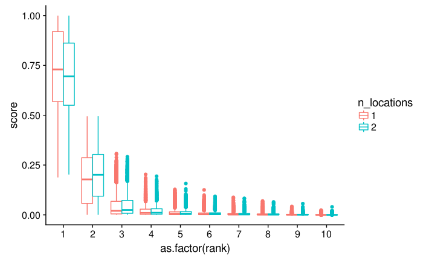

```r
deeploc_score_distrib = deeploc_scores %>%
  filter(n_locations <= 2) %>%
  mutate(n_locations=as.factor(n_locations)) %>%
  group_by(hgnc) %>%
  mutate(rank=rank(-score, ties.method="max")) %>%
  arrange(hgnc)
deeploc_score_distrib %>%
  ggplot(aes(x=as.factor(rank), y=score)) + geom_boxplot(aes(colour=n_locations))
```

## Simple classification by Threshold

The basic idea is, to use a threshold for the highest score. Above a certain threshold, we consider the protein as “having only one subcellular location”. Below the threshold, we consider it as “having two subcellular locations”.

The figur below shows an example for a cutoff of 0.7:

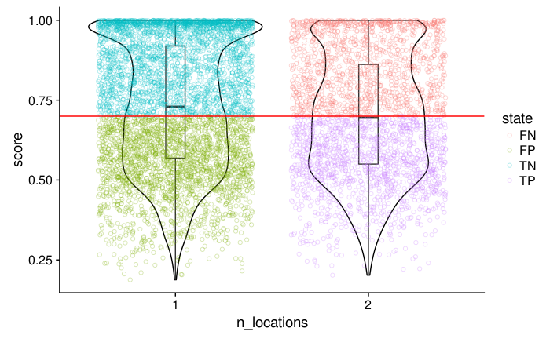

```r
thres = .7
get_state = function(n_pred, n_actual) {
  if(n_pred == 1) {
    if(n_actual == 1) {
      return("TN")
    } else {
      return("FN")
    }
  } else {
    if(n_actual == 2) {
      return("TP")
    } else{
      return("FP")
    }
  }
}
max_score = deeploc_score_distrib %>%
  filter(rank == 1) %>%
  mutate(pred_locations=ifelse(score>thres,1,2)) %>%
  mutate(state=get_state(pred_locations, n_locations))
max_score %>%
  ggplot(aes(x=n_locations, y=score)) +
  geom_violin(col='black') +
  geom_boxplot(width=.1) +
  geom_jitter(alpha=.3, shape=1, aes(colour=state)) +
  geom_hline(yintercept=thres, col='red')
```

## ROC Analysis

To quantify the performance for all thresholds, we perform a ROC analysis. As expected, the overall performance is quite poor with an AUC of 0.54.

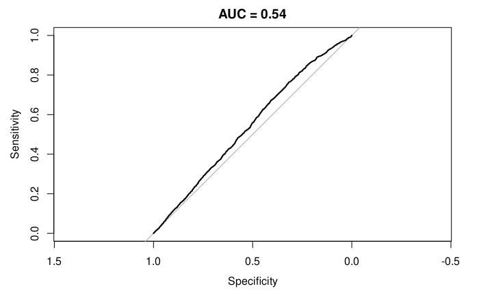

```r
library(pROC)
roc_curve = roc(response=max_score$n_locations, predictor=max_score$score)
plot(roc_curve)
title(paste("AUC =", round(roc_curve$auc, 2)))
```

# Conclusion

We conclude that multiclass prediction from DeepLoc scores alone is not feasible. For further investigation we suggest either

- obtaining unnormalized scores from the Neural Network or
- adding the number of locations as an output to the Neural Network directly.